# Homework 1: Linear Regression

### **Q5 [9 points]**

Let’s read in the data and perform visualization to get a better sense of the data.

**Q5(a) [2 points]** Correctly read in the data stored at `Carseats.csv`.

```r
## Write code solution to Q5(a) here

Car_seats_data <- read.csv("./Carseats.csv", header=T, stringsAsFactors=T)

Car_seats_data
```

```
##     Sales CompPrice Income Advertising Population Price ShelveLoc Age Urban
## 1    9.50       138     73          11        276   120       Bad  42   Yes
## 2   11.22       111     48          16        260    83      Good  65   Yes
## 3   10.06       113     35          10        269    80    Medium  59   Yes
## 4    7.40       117    100           4        466    97    Medium  55   Yes
## 5    4.15       141     64           3        340   128       Bad  38   Yes
## 6   10.81       124    113          13        501    72       Bad  78    No
## 7    6.63       115    105           0         45   108    Medium  71   Yes
## 8   11.85       136     81          15        425   120      Good  67   Yes
## 9    6.54       132    110           0        108   124    Medium  76    No
## 10   4.69       132    113           0        131   124    Medium  76    No
## 11   9.01       121     78           9        150   100       Bad  26    No
## 12  11.96       117     94           4        503    94      Good  50   Yes
## 13   3.98       122     35           2        393   136    Medium  62   Yes
## 14  10.96       115     28          11         29    86      Good  53   Yes
```

[output cut: 386 more lines]

**Q5(b) [2 points]** Produce a scatterplot between `Sales` and `Price`. What is the general pattern from the scatterplot?

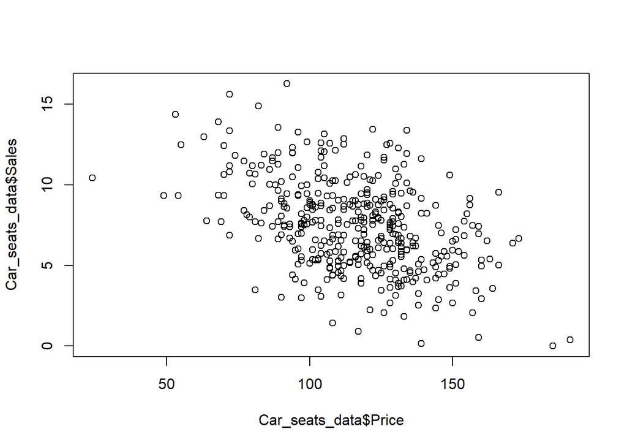

```r
## Write code solution to Q5(b) here
plot(Car_seats_data$Price, Car_seats_data$Sales)
```

Answer:

# The general pattern from the scatter plot shows a negative linear correlation between Price and Sales. This means, all else equal, we can generally expect on average less total unit sales the more expensive the price of car seat.

**Q5(c) [2 points]** Produce a boxplot between `Sales` and `ShelveLoc`. What is the general pattern from the boxplot?

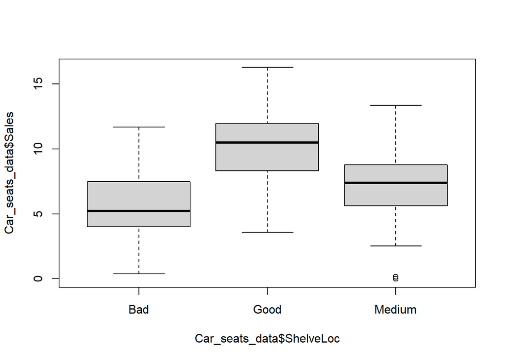

```r
## Write code solution to Q5(c) here

boxplot(Car_seats_data$Sales~Car_seats_data$ShelveLoc)
```

Answer:

# The general pattern we see from the boxplot between Sales and ShelveLoc is that with better quality shelving locations, we expect more overall sales of car seats.

**Q5(d) [3 points]** Produce a histogram of `Sales`. Is `Sales` severely right-skewed?

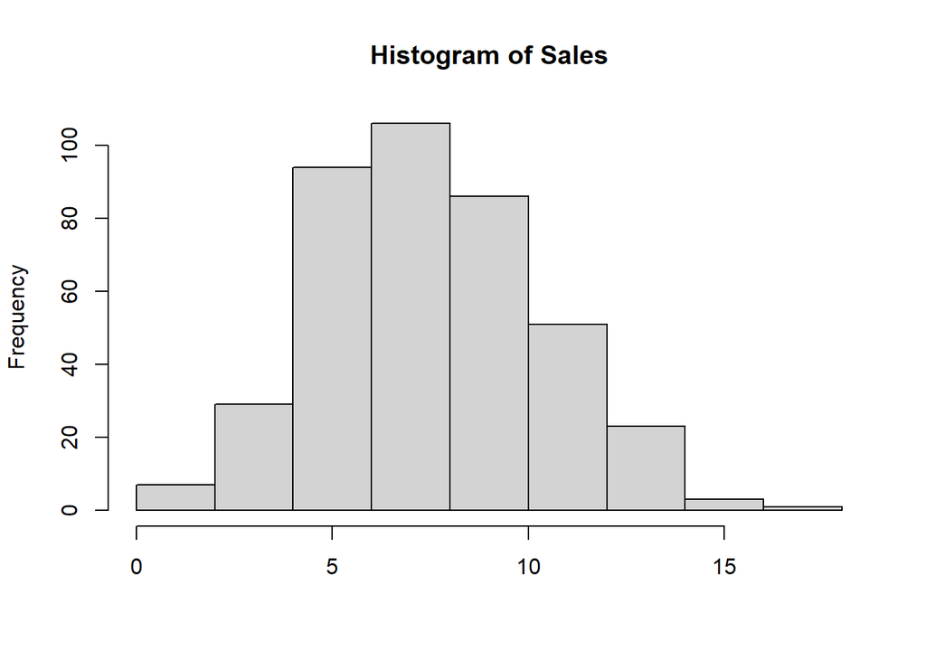

```r
## Write code solution to Q5(d) here

hist(Car_seats_data$Sales, main='Histogram of Sales', xlab='')
```

```r
# the data looks normally distributed with no obvious severe skewness
```

Answer:

### **Q6 [10 points]**

**Q6(a) [4 points]** Fit a linear regression model of the original scale `Sales` w.r.t. all the predictors available in the dataset, name it `lm_full`. Take a look at the summary of `lm_full`.

```r
## Write code solution to Q6(a) here

lm_full <- lm(Sales~CompPrice+Income+Advertising+Population+ Price+ShelveLoc+Age+Urban, data = Car_seats_data)

summary(lm_full)
```

```
##
## Call:
## lm(formula = Sales ~ CompPrice + Income + Advertising + Population +
##     Price + ShelveLoc + Age + Urban, data = Car_seats_data)
##
## Residuals:
##     Min      1Q  Median      3Q     Max
## -2.7868 -0.6988  0.0160  0.6786  3.2736
##
## Coefficients:
##                   Estimate Std. Error t value Pr(>|t|)
## (Intercept)      5.3037420  0.5263440  10.077  < 2e-16 ***
## CompPrice        0.0926753  0.0041490  22.337  < 2e-16 ***
## Income           0.0157694  0.0018400   8.570 2.44e-16 ***
## Advertising      0.1136057  0.0080241  14.158  < 2e-16 ***
## Population       0.0003255  0.0003627   0.897    0.370
## Price           -0.0954335  0.0026720 -35.716  < 2e-16 ***
## ShelveLocGood    4.8538486  0.1530955  31.705  < 2e-16 ***
## ShelveLocMedium  1.9681961  0.1259228  15.630  < 2e-16 ***
## Age             -0.0461324  0.0031829 -14.494  < 2e-16 ***
## UrbanYes         0.1268438  0.1129471   1.123    0.262
## ---
## Signif. codes:  0 '***' 0.001 '**' 0.01 '*' 0.05 '.' 0.1 ' ' 1
##
## Residual standard error: 1.02 on 390 degrees of freedom
## Multiple R-squared:  0.8726, Adjusted R-squared:  0.8697
## F-statistic: 296.9 on 9 and 390 DF,  p-value: < 2.2e-16
```

**Q6(b) [2 points]** What is the estimated coefficient of `lm_full` for CompPrice and Price? How should we interpret the estimated coefficients?

```r
## Write code solution to Q6(b) here
coeff <- lm_full$coefficients

coeff[2]
```

```
##  CompPrice
## 0.09267529
```

```r
coeff[6]
```

```
##      Price
## -0.0954335
```

Answer:

# The estimated coefficients for CompPrice and Price are 0.0926753and -0.0954335, respectively. We can interpet from this data that for every unit increase in CompPrice, we expect on average for the unit Sales to increase by a factor of 0.0926753. Likewise we can interpret that for every unit increase in Price we can expect on average for the unit Sales to decrease by a factor of -0.0954335.

**Q6(c) [2 points]** Which predictor(s) are not statistically significant in the model?

Answer: Population and Urban are not statistically significant predictors in the model.

**Q6(d) [2 points]** What is the $R^2$ of `lm_full`? What are the (in-sample) MAE and RMSE of `lm_full`?

```r
## Write code solution to Q6(d) here

library(forecast)

# RMSE, MAE
error_values <- accuracy(lm_full$fitted.values, Car_seats_data$Sales)

#RMSE
error_values[2]
```

```
## [1] 1.006678
```

```r
#MAE
error_values[3]
```

```
## [1] 0.805898
```

```r
summary(lm_full)$r.squared
```

```
## [1] 0.8726193
```

Answer:

$R^2$ of `lm_full` is 0.8726193 MAE = 0.805898 RMSE = 1.0066781